# Tema 13. Problemas de frontera para ecuaciones diferenciales ordinarias.

## Problemas de frontera para ecuaciones diferenciales ordinarias

## Introducción

En el capítulo de **valores iniciales en ecuaciones diferenciales ordinarias** dada una **ecuación diferencial** del tipo \(y'=f(t,y(t))\) donde \(a\leq t\leq b\), hallábamos una **solución aproximada** al problema anterior dada una **condición inicial** del tipo \(y(a)=y_0\).

Incluso generalizábamos el problema anterior a **ecuaciones diferenciales de órden superior**, es decir, dada una **ecuación diferencial de orden \(m\)**, \(y^{(m)}=f(t,y,y',\ldots,y^{(m-1)})\), donde \(a\leq t\leq b\), hallábamos una **solución aproximada** al problema anterior dada las **condiciones iniciales** del tipo \(y(a)=y_0,\ y'(a)=y'_0,\ y''(a)=y''_0,\ldots, y^{(m-1)}(a)=y^{(m-1)}_0\).

Fijémonos que las **condiciones iniciales** se imponen sólo en el **extremo izquierdo** del intervalo \([a,b]\) de definición de la **variable independiente** \(t\). No hay ninguna condición sobre el **extremo derecho** de dicho intervalo \([a,b]\). De ahí que el problema se denomine **valores iniciales** en ecuaciones diferenciales ordinarias.

## Introducción

Cuando las **condiciones iniciales** de la **ecuación diferencial** incluyen los dos **extremos del intervalo** \([a,b]\) de definición de la **variable independiente** \(t\), el problema a resolver se denomina **problemas de frontera para ecuaciones diferenciales ordinarias**.

En este capítulo, hallaremos **soluciones aproximadas** de **problemas de frontera** donde la **ecuación diferencial** considerada tiene orden \(2\), del tipo \(y''=f(t,y,y')\) y las **condiciones iniciales** son de tipo **frontera**: \(y(a)=y_0,\ y(b)=y_1\).

Como ya hicimos en el capítulo de **valores iniciales en ecuaciones diferenciales ordinarias**, dar la **solución aproximada** significa dar unos valores **discretos** en \(n\) valores del mallado del intervalo \([a,b]\), es decir, fijado un **paso** \(h\), daremos la solución aproximada en los valores \(a+ih\), donde \(h=\frac{b-a}{n}\), \(i=0,\ldots,n\), \(\hat{y}(a+ih)\).

Este tipo de problemas aparecen en **física** e **ingeniería**.

## El método del tiro

## Introducción

El siguiente resultado nos asegura que el **problema frontera** que vamos a resolver tiene **solución única**:

Teorema: existencia y unicidad del problema frontera.

Sea \(f\) una función continua en el conjunto: \[ \mathbf{D}=\{(t,y,y')\ a\leq t\leq b,\ -\infty <y<\infty<\ -\infty< y'<\infty\}, \] y que sus **derivadas parciales** \(\frac{\partial f}{\partial y}\), \(\frac{\partial f}{\partial y'}\) son también continuas en el conjunto \(\mathbf{D}\).

## Introducción

Teorema: existencia y unicidad del problema frontera. (continuación)

Si:

1. \(\frac{\partial f}{\partial y}(t,y,y')>0\), para todo \((t,y,y')\in\mathbf{D}\) y,
2. existe una constante \(M\) tal que \[ \left|\frac{\partial f}{\partial y'}\right|\leq M, \mbox{ para todo }(t,y,y')\in\mathbf{D}, \] el problema de hallar una solución de la ecuación diferencial \(y''=f(t,y,y')\), \(a\leq t\leq b\), con **condiciones iniciales tipo frontera** \(y(a)=y_0,\ y(b)=y_1\) tiene **solución única**.

## Ejemplo

Consideramos el problema siguiente de condiciones iniciales tipo frontera: \[ y''+\sin(5y'+5t)+\mathrm{e}^{2-2(t+1)y}+3=0,\ 0\leq t\leq 1,\ y(0)=0,\ y(1)=2. \] Veamos si tiene solución única.

La función \(f\) será en nuestro caso: \[ f(t,y,y')=-\sin(5y'+5t)-\mathrm{e}^{2-2(t+1)y}-3. \] Dicha función es trivialmente continua al ser suma de funciones continuas.

Sus parciales valen: \[ \frac{\partial f}{\partial y}=\mathrm{e}^{2-2(t+1)y}2(t+1),\quad \frac{\partial f}{\partial y'}=-5\cos(5y'+5t). \] Por tanto, también son continuas.

## Ejemplo (continuación)

La condición 1. se cumple ya que: \[ \frac{\partial f}{\partial y}=\mathrm{e}^{2-2(t+1)y}2(t+1) >0, \] para todo \((t,y,y')\) con \(0\leq t\leq 1\).

Con respecto a la condición 2. tenemos: \[ \left|\frac{\partial f}{\partial y'}\right|=|-5\cos(5y'+5t)|\leq 5. \] Por tanto, también se cumple la condición 2.

Podemos afirmar, por tanto, que el problema anterior de condiciones tipo frontera tiene solución única.

## Problemas lineales con condiciones frontera

Para introducir el **método del tiro**, vamos a hallar una aproximación a **problemas lineales con condiciones frontera** donde la función \(f\) tiene la expresión siguiente: \[ f(t,y,y')=p(t)y'+q(t)y+r(t), \] con \(p(t)\), \(q(t)\) y \(r(t)\) funciones que dependen de la variable independiente \(t\).

Es decir, el problema que nos planteamos es el siguiente:

Problema lineal con condiciones frontera.

Dada una ecuación diferencial de segundo orden de la forma \(y''=p(t)y'+q(t)y+r(t)\), \(a\leq t\leq b\) con \(y(a)=y_0,\ y(b)=y_1\), hallar una solución aproximada \(\hat{y}(t)\) de la ecuación diferencial anterior.

En primer lugar, veamos que dicho problema tiene **solución única** aplicando el Teorema anterior:

## Problemas lineales con condiciones frontera

Corolario: existencia y unicidad de problema lineal tipo frontera.

Sea \(f(t,y,y')=p(t)y'+q(t)y+r(t)\), con \(a\leq t\leq b\) y \(p(t)\), \(q(t)\) y \(r(t)\) funciones que dependen de la variable independiente \(t\).

Supongamos que se verifica lo siguiente:

1. \(p(t)\), \(q(t)\) y \(r(t)\) son continuas en \([a,b]\),
2. \(q(t)>0\) en \([a,b]\).

Entonces el problema lineal con condición frontera siguiente: hallar una solución \(y(t)\) de la ecuación diferencial \(y''=p(t)y'+q(t)y+r(t)\), \(a\leq t\leq b\) con \(y(a)=y_0,\ y(b)=y_1\) tiene solución única.

## Demostración del corolario

Veamos si se verifican las condiciones del Teorema de existencia y unicidad de problemas de ecuaciones diferenciales tipo frontera.

Como las funciones \(p(t),q(t)\) y \(r(t)\) son continuas, también los será la función \(f(t,y,y')=p(t)y'+q(t)y+r(t)\).

Las parciales \(\frac{\partial f}{\partial y}\), \(\frac{\partial f}{\partial y'}\) valen lo siguiente: \[ \frac{\partial f}{\partial y}=q(t),\quad \frac{\partial f}{\partial y'}=p(t). \] Por tanto, son continuas.

Por último veamos que se verifican las condiciones 1. y 2.:

1. \(\frac{\partial f}{\partial y}=q(t)>0\) por hipótesis.
2. \(\frac{\partial f}{\partial y'}=p(t)\) donde \(t\in [a,b]\). Como \([a,b]\) es un intervalo compacto, por el Teorema de Weierstrass (ver el curso **Curso completo de Cálculo en una variable: de cero a experto** para más detalles), existe una constante \(M\) tal que \(|p(t)|\leq M\) para todo \(t\in [a,b]\).

Como se verifican las hipótesis del Teorema, podemos afirmar que el problema lineal con condiciones frontera tiene solución única.

## Problemas lineales con condiciones frontera

Observación.

La razón que se denominen **problemas lineales** es que la función \(f(t,y,y')\) es lineal en las variables \(y\) e \(y'\): \(f(t,y,y')=p(t)y'+q(t)y+r(t)\).

Veamos el siguiente resultado que dice cómo hallar la solución del problema de **condiciones frontera** a partir de dos soluciones de problemas de **valores iniciales**.

## Problemas lineales con condiciones frontera

Proposición. Expresión de la solución del problema lineal con condiciones frontera.

Sea \(y''=p(t)y'+q(t)y+r(t)\), \(a\leq t\leq b\), \(y(a)=y_0,\ y(b)=y_1\) un problema lineal con condiciones frontera, es decir, se trata de hallar una solución \(y(t)\) de la ecuación diferencial anterior que cumpla las **condiciones frontera** indicadas.

Supongamos que las funciones \(p(t),q(t)\) y \(r(t)\) verifican las hipótesis del corolario sobre la **existencia y unicidad** de **soluciones de problemas tipo frontera**.

Sea \(y^{(1)}(t)\) la solución del problema de **condiciones iniciales** siguiente: \[ {y^{(1)}}''=p(t){y^{(1)}}'+q(t)y^{(1)}+r(t),\ a\leq t\leq b,\ y(a)=y_0,\ y'(a)=0. \] Sea \(y^{(2)}(t)\) la solución del problema de **condiciones iniciales** siguiente: \[ {y^{(2)}}''=p(t){y^{(2)}}'+q(t)y^{(2)},\ a\leq t\leq b,\ y(a)=0,\ y'(a)=1. \]

## Problemas lineales con condiciones frontera

Proposición. Expresión de la solución del problema lineal con condiciones frontera. (continuación)

Entonces la solución \(y(t)\) del **problema con condiciones frontera** es el siguiente: \[ y(t)=y^{(1)}(t)+\frac{y_1-y^{(1)}(b)}{y^{(2)}(b)}y^{(2)}(t). \]

## Demostración de la proposición

Veamos en primer lugar que la expresión \(y(t)\) de la proposición verifica la ecuación diferencial: \[ \begin{align*} y''(t) = & {y^{(1)}}''(t)+\frac{y_1-y^{(1)}(b)}{y^{(2)}(b)}{y^{(2)}}''(t)=p(t){y^{(1)}}'(t)+q(t)y^{(1)}(t)+r(t)+\frac{y_1-y^{(1)}(b)}{y^{(2)}(b)}(p(t){y^{(2)}}'(t)+q(t)y^{(2)}(t))\\ = & p(t)\left({y^{(1)}}'(t)+\frac{y_1-y^{(1)}(b)}{y^{(2)}(b)}{y^{(2)}}'(t)\right)+q(t)\left({y^{(1)}}(t)+\frac{y_1-y^{(1)}(b)}{y^{(2)}(b)}{y^{(2)}}(t)\right)+r(t)\\ = & p(t)y'(t)+q(t)y(t)+r(t), \end{align*} \] tal como queríamos ver.

Veamos por último que \(y(t)\) verifica las condiciones frontera: \[ \begin{align*} y(a) = & y^{(1)}(a)+\frac{y_1-y^{(1)}(b)}{y^{(2)}(b)}y^{(2)}(a)=y_0+\frac{y_1-y^{(1)}(b)}{y^{(2)}(b)}\cdot 0=y_0,\\ y(b) = & y^{(1)}(b)+\frac{y_1-y^{(1)}(b)}{y^{(2)}(b)}y^{(2)}(b)=y^{(1)}(b)+\frac{y_1-y^{(1)}(b)}{y^{(2)}(b)}\cdot y^{(2)}(b)=y^{(1)}(b)+y_1-y^{(1)}(b)=y_1, \end{align*} \] tal como queríamos ver.

## Problemas lineales con condiciones frontera

**Ejercicio**

Demostrar que los problemas de valores iniciales de la proposición anterior tienen solución única.

Indicación: transformar las ecuaciones diferenciales de segundo orden que verifican las funciones \(y^{(1)}(t)\) e \(y^{(2)}(t)\) en un sistema de dos ecuaciones diferenciales y demostrar que la “parte derecha” de los sistemas anteriores verifican la condición de Lipschitz con una determinada constante \(L\) usando la continuidad de las funciones \(p(t),q(t)\) y \(r(t)\).

## Problemas lineales con condiciones frontera

Entonces, para hallar la solución aproximada \(\hat{y}(t_i)\) en el mallado \(t_i=a+ih\), \(i=0,\ldots,n\), \(h=\frac{b-a}{n}\) que verifique las **condiciones frontera**,

- primero tenemos que calcular las aproximaciones \({\hat{y}}^{(1)}\) y \({\hat{y}}^{(2)}\) de los problemas de **valores iniciales** siguientes usando un método de resolución visto en el capítulo de **Problemas de valores iniciales en ecuaciones diferenciales ordinarias**: \[ \begin{align*} {y^{(1)}}'' = & p(t){y^{(1)}}'+q(t)y^{(1)}+r(t), &\ a\leq t\leq b,\ y^{(1)}(a)=y_0,\ {y^{(1)}}'(a)=0,\\ {y^{(2)}}'' = & p(t){y^{(2)}}'+q(t)y^{(2)}, &\ a\leq t\leq b,\ y^{(2)}(a)=0,\ {y^{(2)}}'(a)=1. \end{align*} \]
- a continuación, aplicar la expresión dada en la proposición. Entonces, la solución aproximada en el mallado anterior será: \[ \hat{y}(t_i)={\hat{y}}^{(1)}(t_i)+\frac{y_1-{\hat{y}}^{(1)}(b)}{{\hat{y}}^{(2)}(b)}{\hat{y}}^{(2)}(t_i),\ i=0,\ldots,n. \]

## Método del tiro. Pseudocódigo

Vamos a dar el pseudocódigo donde se usa el método de **Runge Kutta 4** para resolver los problemas de **valores iniciales** correspondientes a las dos **ecuaciones diferenciales** de segundo orden.

Suponemos pues que tenemos definida una rutina usando el pseudocódigo del capítulo de **Problemas de valores iniciales en ecuaciones diferenciales** que implementa el método de Runge-Kutta 4. Llamaremos a dicha rutina `RK4-sistemas(a,b,h,m,y00,g)` donde los valores `a` y `b` corresponden a los valores inicial y final respecto la variable \(t\), `h` es el paso del mallado, `m` es el número de ecuaciones, `y00` sería el vector de condiciones iniciales y `g` la función que tiene \(m\) componentes respecto las variables \(t,y_1,\ldots,y_m\).

## Método del tiro. Pseudocódigo

Es decir, el método da una aproximación a la resolución del **problema de valores iniciales** siguiente:

\[ \begin{align*} y_1'(t) & = g_1(t,y_1(t),\ldots,y_m(t)),\\ y_2'(t) & = g_2(t,y_1(t),\ldots,y_m(t)),\\ & \vdots\\ y_m'(t) & = g_m(t,y_1(t),\ldots,y_m(t)), \end{align*} \] para \(t\in [a,b]\) y **condiciones iniciales**: \[ y_1(a)=y_{01},\ y_2(a)=y_{02},\ldots,y_m(a)=y_{0m}. \] Concretamente, da como resultado una matriz \(\mathbf{\hat{Y}}\), de dimensiones \(m\times (n+1)\) donde la componente \(i,j\) de dicha matriz sería la aproximación de la componente \(i\)-ésima en el valor \(j\)-ésimo del mallado: \[ y_{ij}=\hat{y}_i(t_j)=\hat{y}_i(a+(j-1)h),\ i=1,\ldots,m,\ j=1,\ldots,n+1. \]

## Método del tiro. Pseudocódigo

Los sistemas de ecuaciones diferenciales correspondientes a los **problemas de valores iniciales** considerados son los siguientes:

- Solución \(y^{(1)}\): \[ \begin{align*} y_1'(t) & = y_2,\\ y_2'(t) & = p(t)y_2+q(t)y_1+r(t), \end{align*} \] con \(a\leq t\leq b\) y condiciones iniciales \(y_1(a)=y_0\), \(y_2(a)=0\).

## Método del tiro. Pseudocódigo

- Solución \(y^{(2)}\): \[ \begin{align*} y_1'(t) & = y_2,\\ y_2'(t) & = p(t)y_2+q(t)y_1, \end{align*} \] con \(a\leq t\leq b\) y condiciones iniciales \(y_1(a)=0\), \(y_2(a)=1\).

## Método del tiro. Pseudocódigo

Supondremos que la salida de la rutina es una matriz \(\mathbf{Y}\) de dimensiones \(m\times (n+1)\) donde la componente \((i,j)\), \(\mathbf{Y}_{ij}\) sería \(\mathbf{y}_i(t_j)=\mathbf{y}_i(a+hj)\), es decir, el valor de la componente \(\hat{y}_i\) en el punto del mallado \(t_j=a+hj\).

- `INPUT a,b, y0, y1, n, p, q, r, RK4-sistemas` (`nos dan los valores inicial y final del intervalo` \([a,b]\), `los valores` \(y(a)=y_0\) `e` \(y(b)=y_1\), `el número de valores del mallado` \(n\), `las funciones` \(p\), \(q\) `y` \(r\) `y la rutina de resolución de los problemas de valores iniciales, en nuestro caso, el método de Runge-Kutta 4, RK4-sistemas`)
- `Set` \(h=\frac{b-a}{n}\). (`calculamos el paso del mallado`)

## Método del tiro. Pseudocódigo

- `Rutina g1(t,y1,y2)` (`Definimos la función` \(\mathbf{g}_1\) `para hallar la aproximación` \(\hat{y}^{(1)}\))
  - `Return` \((y_2,p(t)\cdot y_2+q(t)\cdot y_1+r(t))\)
- `Set` \(\mathbf{Y}_1 = RK4-sistemas(a,b,h,2,(y_0,0),\mathbf{g}_1)\) (`Calculamos la aproximación` \(\hat{y}^{(1)}\))
- `Rutina g2(t,y1,y2)` (`Definimos la función` \(\mathbf{g}_2\) `para hallar la aproximación` \(\hat{y}^{(2)}\))
  - `Return` \((y_2,p(t)\cdot y_2+q(t)\cdot y_1)\)
- `Set` \(\mathbf{Y}_2 = RK4-sistemas(a,b,h,2,(0,1),\mathbf{g}_2)\) (`Calculamos la aproximación` \(\hat{y}^{(2)}\))

## Método del tiro. Pseudocódigo

- `Set` \(\mathbf{Y}=\mathbf{Y}_1[1,]+\frac{(y_1-\mathbf{Y}_1[1,n+1])}{\mathbf{Y}_2[1,n+1]}\cdot\mathbf{Y}_2[1,]\) (`Calculamos la aproximación del problema de valores frontera usando la expresión vista en la proposición`)
- `Print` \(\mathbf{Y}\).

Fijémonos que en la última expresión para calcular \(\mathbf{Y}\), la aproximación del problema de valores frontera, hemos considerado la primera componente de las aproximaciones \(\mathbf{Y}_1\) e \(\mathbf{Y}_2\) que es la componente que aproxima \(y^{(1)}\) e \(y^{(2)}\) respectivamente.

## Ejemplo

Vamos a hallar la solución aproximada del siguiente problema de **valores frontera**: \[ y''=\frac{t}{5} y'(t)+\left(2 t+\frac{1}{10}\right) y(t)-\cos t,\ 0\leq t\leq 2,\ y(0)=1,\ y(2)=4. \] Usaremos el método de Runge-Kutta 4 para resolver los dos problemas de valores iniciales.

Consideraremos el mallado con \(h=0.1\): \[ t_i=0, 0.1, 0.2, 0.3, 0.4, 0.5, 0.6, 0.7, 0.8, 0.9, 1, 1.1, 1.2, 1.3, 1.4, 1.5, 1.6, 1.7, 1.8, 1.9, 2. \] Fijémonos que el sistema anterior cumple las condiciones de la proposición ya que \(q(t)=2t+\frac{1}{10}> 0\).

Los valores \({\hat{y}}^{(1)}(t_i)\) y \({\hat{y}}^{(2)}(t_i)\) son aproximaciones de los problemas siguientes de valores iniciales: \[ \begin{align*} {y^{(1)}}''= & \frac{t}{5} {y^{(1)}}'+\left(2 t+\frac{1}{10}\right) y^{(1)}-\cos t,\ 0\leq t\leq 2,\ y^{(1)}(0)=1,\ {y^{(1)}}'(0)=0,\\ {y^{(2)}}''= & \frac{t}{5} {y^{(2)}}'+\left(2 t+\frac{1}{10}\right) y^{(2)},\ 0\leq t\leq 2,\ y^{(2)}(0)=0,\ {y^{(2)}}'(0)=1. \end{align*} \]

La tabla siguiente muestra la solución aproximada \({\hat{y}}^{(1)}(t_i)\) en los puntos del mallado:

## Ejemplo (continuación)

| \(t_i\) | \(\hat{y}_i^{(1)}\) | \({\hat{y}_i^{(1)}}'\) |
| --- | --- | --- |
| 0 | 1 | 0 |
| 0.1 | 0.9958353 | -0.0799234 |
| 0.2 | 0.9846941 | -0.1394913 |
| 0.3 | 0.9686203 | -0.1785599 |
| 0.4 | 0.9496669 | -0.1970753 |
| 0.5 | 0.9298938 | -0.1949182 |
| 0.6 | 0.9113829 | -0.1717446 |
| 0.7 | 0.8962687 | -0.1268189 |

## Ejemplo (continuación)

| \(t_i\) | \(\hat{y}_i^{(1)}\) | \({\hat{y}_i^{(1)}}'\) |
| --- | --- | --- |
| 0.8 | 0.8867863 | -0.0588301 |
| 0.9 | 0.8853393 | 0.034318 |
| 1 | 0.8945903 | 0.155758 |
| 1.1 | 0.9175799 | 0.3099695 |
| 1.2 | 0.9578797 | 0.5031749 |
| 1.3 | 1.0197917 | 0.7438528 |
| 1.4 | 1.1086057 | 1.0434154 |
| 1.5 | 1.2309359 | 1.4171086 |

## Ejemplo (continuación)

| \(t_i\) | \(\hat{y}_i^{(1)}\) | \({\hat{y}_i^{(1)}}'\) |
| --- | --- | --- |
| 1.6 | 1.3951615 | 1.885218 |
| 1.7 | 1.6120075 | 2.4746927 |
| 1.8 | 1.8953156 | 3.22134 |
| 1.9 | 2.2630709 | 4.1728052 |
| 2 | 2.7387786 | 5.3926279 |

La tabla siguiente muestra la solución aproximada \({\hat{y}}^{(2)}(t_i)\) en los puntos del mallado:

## Ejemplo (continuación)

| \(t_i\) | \(\hat{y}_i^{(2)}\) | \({\hat{y}_i^{(2)}}'\) |
| --- | --- | --- |
| 0 | 0 | 1 |
| 0.1 | 0.1000667 | 1.0021682 |
| 0.2 | 0.2006678 | 1.0113672 |
| 0.3 | 0.302712 | 1.0317343 |
| 0.4 | 0.4075319 | 1.0676385 |
| 0.5 | 0.5169155 | 1.1238506 |
| 0.6 | 0.6331572 | 1.2057675 |
| 0.7 | 0.7591339 | 1.3197014 |

## Ejemplo (continuación)

| \(t_i\) | \(\hat{y}_i^{(2)}\) | \({\hat{y}_i^{(2)}}'\) |
| --- | --- | --- |
| 0.8 | 0.8984148 | 1.4732511 |
| 0.9 | 1.0554123 | 1.6757774 |
| 1 | 1.2355882 | 1.939017 |
| 1.1 | 1.4457285 | 2.2778775 |
| 1.2 | 1.694311 | 2.7114762 |
| 1.3 | 1.9919907 | 3.2645058 |
| 1.4 | 2.3522435 | 3.9690409 |
| 1.5 | 2.7922191 | 4.8669409 |

## Ejemplo (continuación)

| \(t_i\) | \(\hat{y}_i^{(2)}\) | \({\hat{y}_i^{(2)}}'\) |
| --- | --- | --- |
| 1.6 | 3.3338718 | 6.0130638 |
| 1.7 | 4.005466 | 7.479583 |
| 1.8 | 4.8435836 | 9.3618117 |
| 1.9 | 5.895813 | 11.786094 |
| 2 | 7.2243604 | 14.9205366 |

## Ejemplo (continuación)

Entonces la solución aproximada del problema de **valores frontera** será: \[ \hat{y}(t_i)={\hat{y}}^{(1)}(t_i)+\frac{(4-{\hat{y}}^{(1)}(2))}{{\hat{y}}^{(2)}(2)}\cdot {\hat{y}}^{(2)}(t_i)={\hat{y}}^{(1)}(t_i)+\frac{(4-2.7387786)}{7.2243604}\cdot {\hat{y}}^{(2)}(t_i)={\hat{y}}^{(1)}(t_i)+ 0.174579\cdot {\hat{y}}^{(2)}(t_i). \] Calculemos los primeros valores: \[ \begin{align*} \hat{y}(t_0) = & \hat{y}(0)={\hat{y}}^{(1)}(0)+0.174579\cdot {\hat{y}}^{(2)}(0)=1+0.174579\cdot 0=1,\\ \hat{y}(t_1) = & \hat{y}(0.1)={\hat{y}}^{(1)}(0.1)+0.174579\cdot {\hat{y}}^{(2)}(0.1)=0.9958353+0.174579\cdot 0.1000667=1.0133049,\\ \hat{y}(t_2) = & \hat{y}(0.2)={\hat{y}}^{(1)}(0.2)+0.174579\cdot {\hat{y}}^{(2)}(0.2)=0.9846941+0.174579\cdot 0.2006678=1.0197265,\\ \hat{y}(t_3) = & \hat{y}(0.3)={\hat{y}}^{(1)}(0.3)+0.174579\cdot {\hat{y}}^{(2)}(0.3)=0.9686203+0.174579\cdot 0.302712=1.0214675,\\ & \vdots \end{align*} \] La tabla siguiente muestra los valores de la aproximación \(\hat{y}(t_i)\) en el mallado:

## Ejemplo (continuación)

| \(t_i\) | \(\hat{y}_i\) |
| --- | --- |
| 0 | 1 |
| 0.1 | 1.0133049 |
| 0.2 | 1.0197265 |
| 0.3 | 1.0214675 |
| 0.4 | 1.0208134 |
| 0.5 | 1.0201363 |
| 0.6 | 1.0219188 |
| 0.7 | 1.0287975 |

## Ejemplo (continuación)

| \(t_i\) | \(\hat{y}_i\) |
| --- | --- |
| 0.8 | 1.0436306 |
| 0.9 | 1.0695921 |
| 1 | 1.1102981 |
| 1.1 | 1.1699737 |
| 1.2 | 1.2536708 |
| 1.3 | 1.3675513 |
| 1.4 | 1.5192579 |
| 1.5 | 1.7183987 |

## Ejemplo (continuación)

| \(t_i\) | \(\hat{y}_i\) |
| --- | --- |
| 1.6 | 1.9771854 |
| 1.7 | 2.3112777 |
| 1.8 | 2.7409034 |
| 1.9 | 3.2923559 |
| 2 | 4 |

La gráfica siguiente muestra la solución aproximada \({\hat{y}}^{(1)}_i\) en negro, la solución aproximada \({\hat{y}}^{(2)}_i\) en azul y la solución del problema de valores frontera en rojo.

El nombre de el **método del tiro** viene que tenemos que llegar al punto \((b=2,y_1=4)\) desde \((a=0,y_0=1)\). En este caso, con un sólo “disparo” llegamos a nuestro destino gracias a la ayuda de las aproximaciones auxiliares \({\hat{y}}^{(1)}_i\) y \({\hat{y}}^{(2)}_i\).

## Ejemplo (continuación)

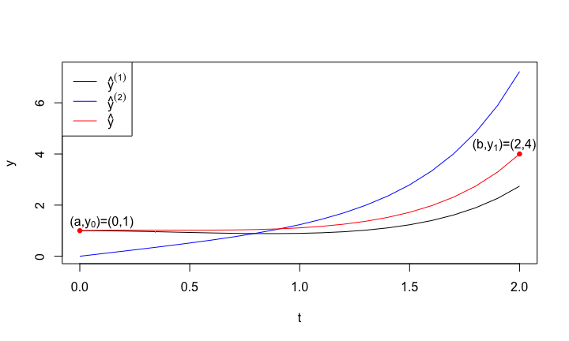

## Método del tiro para sistemas no lineales

Vamos a generalizar el **método del tiro** a **problemas de valores frontera** para ecuaciones **diferenciales de segundo orden no lineales**: \[ y''=f(t,y,y'),\ a\leq t\leq b,\ y(a)=y_0,\ y(b)=y_1. \]

En este caso, no podemos escribir la solución aproximada \(\hat{y}(t)\) del **problema de valores frontera** como **combinación lineal** de las soluciones aproximadas de dos **problemas de valores iniciales** tal como hicimos en el caso **lineal**.

Podemos interpretar el problema a resolver de la forma siguiente:

## Método del tiro para sistemas no lineales

Problema de valores frontera.

Hallar la **condición inicial** \(y_0'\) del problema de **valor inicial** \[ y''=f(t,y,y'),\ a\leq t\leq b,\ y(a)=y_0,\ y'(a)=y_0', \] tal que \(y(b)=y_1.\)

Dicho de otra forma, se trata de determinar cuál es la **pendiente inicial** \(y_0'\) con la que debemos *partir* para que al final lleguemos a la **condición frontera** \(y(b)=y_1\).

El gráfico siguiente muestra lo que se intenta solucionar: hallar la pendiente \(y_0'\) tal que la solución aproximada alcance el punto rojo en \(t=b\).

## Método del tiro para sistemas no lineales

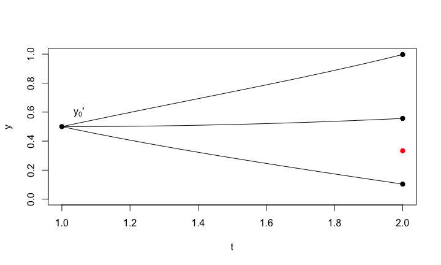

## Método del tiro para sistemas no lineales

Para solucionar el **problema del tiro para sistemas no lineales**, escribamos la solución del **problema de valor inicial** \[ y''=f(t,y,y'),\ a\leq t\leq b,\ y(a)=y_0,\ y'(a)=y_0', \] de la forma \(y(t,y_0,y_0')\) indicando que depende del **tiempo** \(t\) y de las **condiciones iniciales** \(y_0\) e \(y_0'\).

Entonces, el **problema de valores frontera** se reduce a hallar un **cero** de la función siguiente: \[ g(y_0')=y(b,y_0,y_0')-y_1=0, \] donde los valores de \(b\), \(y_0\) e \(y_1\) son fijos y el valor que vamos variando es la **pendiente inicial** \(y_0'\).

## Método del tiro para sistemas no lineales

El el tema de **ceros** del curso **Métodos numéricos con Python. Cálculo Numérico** vimos todo un conjunto de métodos para hallar **ceros** de funciones de una variable real.

Entre ellos, estaba el **método de la secante** que consistía en hallar una sucesión \((y_{0,k}')_{k\geq 0}\) de la forma siguiente: \[ \begin{align*} y_{0,k}' = & y_{0,k-1}'-\frac{g(y_{0,k-1}')(y_{0,k-1}'-y_{0,k-2}')}{g(y_{0,k-1}')-g(y_{0,k-2}')}\\ = & y_{0,k-1}'-\frac{(y(b,y_0,y_{0,k-1}')-y_1)(y_{0,k-1}'-y_{0,k-2}')}{y(b,y_0,y_{0,k-1}')-y(b,y_0,y_{0,k-2}')}, \end{align*} \] eligiendo dos valores iniciales \(y_{0,0}'\) e \(y_{0,1}'\).

## Método del tiro para sistemas no lineales

Por último, una vez hallada la aproximación \(y_{0,k}'\) con la tolerancia permitida se resuelve el siguiente problema de valores iniciales: \[ y''=f(t,y,y'),\ a\leq t\leq b,\ y(a)=y_0,\ y'(a)=y_{0,k}'. \]

## Método de la secante. Pseudocódigo

- `INPUT a,b, y0, y1, n, f, RK4-sistemas` (`nos dan los valores inicial y final del intervalo` \([a,b]\), `los valores` \(y(a)=y_0\) `e` \(y(b)=y_1\), `el número de valores del mallado` \(n\), `la función` \(f(t,y,y')\), `la rutina de resolución de los problemas de valores iniciales, en nuestro caso, el método de Runge-Kutta 4, RK4-sistemas`), `los valores iniciales` \(y_{0,0}'\) `e` \(y_{0,1}'\), `la tolerancia` \(TOL\) `y el número máximo de iteraciones` \(Nmax\).
- `Rutina F(t,y1,y2)` (`Definimos la función` \(\mathbf{F}\) `para hallar la aproximación` \(\hat{y}\))
  - `Return` \((y_2,f(t,y_1,y_2))\)
- `Rutina y(y0')` (`Rutina que da el valor` \(y(b,y_0,y_0')\) `dada una pendiente inicial` \(y_0'\))
  - `Return` \(RK4-sistemas(a,b,h,2,(y_0,y_0'),\mathbf{F})\)

## Método de la secante. Pseudocódigo

- `Set` \(h=\frac{b-a}{n}\). (`calculamos el paso del mallado`)
- `Set` \(k=1\) (`inicializamos el contador que da el número de iteraciones`)
- `While` \(k\leq Nmax\)
  - `Set` \(y_0'=y_{0,1}'-\frac{(y(b,y_0,y_{0,1}')-y_1)(y_{0,1}'-y_{0,0}')}{y(b,y_0,y_{0,1}')-y(b,y_0,y_{0,0}')}\).
  - `If` \(|y_0'-y_{0,1}'|\leq TOL\)
    - `Print: El valor de la pendiente inicial vale`
    - `Print` \(y_0'\).
    - `Print: La solución aproximada vale`
    - `Print:` \(RK4-sistemas(a,b,h,2,(y_0,y_0'),\mathbf{F})\)
    - `STOP`.

## Método de la secante. Pseudocódigo

- - `Set` \(y_{0,0}'=y_{0,1}'\).
  - `Set` \(y_{0,1}'=y_0'\).
  - `Set` \(k=k+1\).
- `Print: El método no converge al cabo de Nmax iteraciones`.

## Ejemplo

Vamos a hallar la solución aproximada del siguiente problema de **valores frontera**: \[ y''=y^3-yy',\ 1\leq t\leq 2,\ y(1)=\frac{1}{2},\ y(2)=\frac{1}{3}, \] aplicando el método de la secante usando como aproximaciones iniciales \(y_{0,0}'=-0.5,\ y_{0,1}'=0.5\).

Vamos a usar el método de Runge-Kutta 4 para hallar las soluciones aproximadas de los problemas de valores iniciales.

- Cálculo de \(y_{0,2}'\). Los valores finales \(y(2,0.5,y_{0,0}')=y(2,0.5,-0.5)\) y \(y(2,0.5,y_{0,1}')=y(2,0.5,0.5)\) valen: \[ y(2,0.5,-0.5)=0.1036881,\quad y(2,0.5,0.5)=0.9970875. \] El siguiente valor de la iteración \(y_{0,2}'\) será: \[ \begin{align*} y_{0,2}'= & y_{0,1}'-\frac{(y(b,y_0,y_{0,1}')-y_1)(y_{0,1}'-y_{0,0}')}{y(b,y_0,y_{0,1}')-y(b,y_0,y_{0,0}')}=0.5-\frac{(0.9970875-0.3333333)(0.5-(-0.5))}{0.9970875-0.1036881}\\= & -0.2429534. \end{align*} \]

## Ejemplo (continuación)

- Cálculo de \(y_{0,3}'\). El valor final \(y(2,0.5,y_{0,2}')=y(2,0.5,-0.2429534)\) vale: \[ y(2,0.5,-0.2429534)=0.3396923. \] El siguiente valor de la iteración \(y_{0,3}'\) será: \[ \begin{align*} y_{0,3}'= & y_{0,2}'-\frac{(y(b,y_0,y_{0,2}')-y_1)(y_{0,2}'-y_{0,1}')}{y(b,y_0,y_{0,2}')-y(b,y_0,y_{0,1}')}\\ = & -0.2429534-\frac{(0.3396923-0.3333333)(-0.2429534-0.5)}{0.3396923-0.9970875}= -0.25014. \end{align*} \]
- Y así sucesivamente.

La tabla siguiente nos muestra la sucesión \((y_{0,k}')_{k\geq 0}\) con una tolerancia de \(0.000001\).

## Ejemplo (continuación)

| \(k\) | \(y_{0,k}'\) | \(y(2,0.5,y_{0,k}')\) | \(\|y(2,0.5,y_{0,k}')-y(2,0.5,y_{0,k-1}')\|\) |
| --- | --- | --- | --- |
| \(0\) | \(-0.5\) | \(0.1036881\) |  |
| \(1\) | \(0.5\) | \(0.9970875\) | \(1\) |
| \(2\) | \(-0.2429534\) | \(0.3396923\) | \(0.7429534\) |
| \(3\) | \(-0.25014\) | \(0.333207\) | \(0.0071865\) |
| \(4\) | \(-0.25\) | \(0.3333334\) | \(0.00014\) |
| \(5\) | \(-0.25\) | \(0.3333333\) | \(0.0000001\) |

La tabla siguiente muestra la aproximación \(\hat{y}(t_i)\) en el mallado \[ 1, 1.05, 1.1, 1.15, 1.2, 1.25, 1.3, 1.35, 1.4, 1.45, 1.5, 1.55, 1.6, 1.65, 1.7, 1.75, 1.8, 1.85, 1.9, 1.95, 2 \] usando como \(y_0'\) la aproximación hallada: \(-0.25\):

## Ejemplo (continuación)

| \(t_i\) | \(\hat{y}_i\) | \(\hat{y}_i'\) |
| --- | --- | --- |
| 1 | 0.5 | -0.25 |
| 1.05 | 0.4878049 | -0.2379536 |
| 1.1 | 0.4761905 | -0.2267574 |
| 1.15 | 0.4651163 | -0.2163332 |
| 1.2 | 0.4545455 | -0.2066116 |
| 1.25 | 0.4444444 | -0.1975309 |
| 1.3 | 0.4347826 | -0.1890359 |
| 1.35 | 0.4255319 | -0.1810774 |

## Ejemplo (continuación)

| \(t_i\) | \(\hat{y}_i\) | \(\hat{y}_i'\) |
| --- | --- | --- |
| 1.4 | 0.4166667 | -0.1736111 |
| 1.45 | 0.4081633 | -0.1665973 |
| 1.5 | 0.4 | -0.16 |
| 1.55 | 0.3921569 | -0.153787 |
| 1.6 | 0.3846154 | -0.147929 |
| 1.65 | 0.3773585 | -0.1423994 |
| 1.7 | 0.3703704 | -0.1371742 |
| 1.75 | 0.3636364 | -0.1322314 |

## Ejemplo (continuación)

| \(t_i\) | \(\hat{y}_i\) | \(\hat{y}_i'\) |
| --- | --- | --- |
| 1.8 | 0.3571429 | -0.127551 |
| 1.85 | 0.3508772 | -0.1231148 |
| 1.9 | 0.3448276 | -0.1189061 |
| 1.95 | 0.3389831 | -0.1149095 |
| 2 | 0.3333333 | -0.1111111 |

## Método de Newton-Raphson

Otro método que vimos en el tema de **ceros** del curso **Métodos numéricos con Python. Cálculo Numérico** es el **método de Newton-Raphson**.

Es uno de los métodos más usados sobre todo por su rápida convergencia ya que si el **cero** es **simple**, tiene **convergencia cuadrática**.

Recordemos que tenemos que hallar un **cero** de la función \(g(y_0')=y(b,y_0,y_0')-y_1=0\). La sucesión que da el **método de Newton-Raphson** verifica la **recurrencia siguiente**: \[ y_{0,k}' = y_{0,k-1}'-\frac{g(y_{0,k-1}')}{g'(y_{0,k-1}')}= y_{0,k-1}'-\frac{(y(b,y_0,y_{0,k-1}')-y_1)}{g'(y_{0,k-1}')}, \] a partir de un valor inicial \(y_{0,0}'\).

## Método de Newton-Raphson

El valor de \(g'(y_0')\) en un valor \(y_0'\) cualquiera será: \[ g'(y_0')=\frac{\partial{y(b,y_0,y_0')}}{\partial y_0'}. \] La cuestión que se nos plantea es cómo hallamos la parcial anterior \(\frac{\partial{y(b,y_0,y_0')}}{\partial y_0'}\) de cara a poder aplicar el **método de Newton-Raphson**.

Para resolver la cuestión anterior, definimos la función siguiente \(z(t,y_0,y_0')=\frac{\partial{y(t,y_0,y_0')}}{\partial y_0'}\). De esta manera, nuestro problema se reduce a hallar \(z(b,y_0,y_0')\).

Para hallar \(z(b,y_0,y_0')\) vamos a calcular la **ecuación diferencial** que verifica y que integraremos numéricamente desde \(t=a\) hasta \(t=b\).

## Método de Newton-Raphson

Recordemos que \(y=y(t,y_0,y_0')\) es la solución del problema de **valores iniciales**: \[ \begin{align*} & y''(t,y_0,y_0')= f(t,y(t,y_0,y_0'),y'(t,y_0,y_0')),\\ & a\leq t\leq b,\ y(a,y_0,y_0')=y_0,\ y(b,y_0,y_0')=y_1, \end{align*} \] donde hemos indicado explícitamente la dependencia de la solución de dicho problema respecto el tiempo \(t\) y respecto las **condiciones iniciales** \(y_0\) e \(y_0'\).

Si calculamos la parcial con respecto \(y_0'\) en la ecuación diferencial anterior obtenemos: \[ \frac{\partial y''(t,y_0,y_0')}{\partial y_0'}=\frac{\partial f(t,y(t,y_0,y_0'),y'(t,y_0,y_0'))}{\partial y_0'}. \]

## Método de Newton-Raphson

Usando el **Teorema de Schwartz o Teorema de Clairaut o Teorema de Young** (https://es.wikipedia.org/wiki/Teorema_de_Clairaut) que dice que podemos permutar la parcial anterior con la derivada segunda respecto el tiempo \(t\) y usando la **regla de la cadena** podemos hallar la ecuación diferencial de segundo orden que verifica la función \(z(t,y_0,y_0')\): \[ \begin{align*} \frac{\partial y''(t,y_0,y_0')}{\partial y_0'}= & z''(t,y_0,y_0')\\ = & \frac{\partial f(t,y(t,y_0,y_0'),y'(t,y_0,y_0'))}{\partial y}\cdot\frac{\partial y(t,y_0,y_0')}{\partial y_0'}\\ & \quad +\frac{\partial f(t,y(t,y_0,y_0'),y'(t,y_0,y_0'))}{\partial y'}\cdot\frac{\partial y'(t,y_0,y_0')}{\partial y_0'} \\ = & \frac{\partial f(t,y,y')}{\partial y}\cdot z(t)+\frac{\partial f(t,y,y')}{\partial y'}\cdot z'(t). \end{align*} \]

## Método de Newton-Raphson

En resumen, la función \(z(t)\) verifica la ecuación diferencial de segundo orden siguiente: \[ z''(t)=\frac{\partial f(t,y,y')}{\partial y}\cdot z(t)+\frac{\partial f(t,y,y')}{\partial y'}\cdot z'(t). \] Por último, falta hallar las condiciones iniciales para la función \(z(t,y_0,y_0')\).

Usando que \(y(a,y_0,y_0')=y_0\), realizando la parcial respecto \(y_0'\), obtenemos que: \[ z(a)=\frac{\partial y(a,y_0,y_0')}{\partial y_0'}=0, \] y usando que \(y'(a,y_0,y_0')=y_0'\), realizando la parcial respecto \(y_0'\), obtenemos que: \[ z'(a)=\frac{\partial y'(a,y_0,y_0')}{\partial y_0'}=1. \]

## Método de Newton-Raphson

La función \(z(t)\) es la solución del siguiente **problema de valores iniciales**: \[ z''=\frac{\partial f(t,y,y')}{\partial y}\cdot z(t)+\frac{\partial f(t,y,y')}{\partial y'}\cdot z'(t),\ a\leq t\leq b,\ z(a)=0,\ z'(a)=1. \]

Como dicho sistema depende de \(y(t)\) e \(y'(t)\), tenemos que integrar dicha ecuación diferencial junto con la ecuación diferencial que verifica \(y(t)\) resultando el siguiente **sistema de ecuaciones diferenciales**: \[ \begin{align*} y''= & f(t,y,y'),\\ z''=& \frac{\partial f(t,y,y')}{\partial y}\cdot z(t)+\frac{\partial f(t,y,y')}{\partial y'}\cdot z'(t), \end{align*} \] con \(a\leq t\leq b\) y condiciones iniciales \(y(a)=y_0,\ y'(a)=y_0',\ z(a)=0,\ z'(a)=1\) obteniéndose \(y(b)\) y \(z(b)\).

## Método de Newton-Raphson

Vamos a escribir el sistema anterior como un **sistema de ecuaciones diferenciales de primer orden** de \(4\) ecuaciones con \(4\) funciones a determinar.

Para ello, definimos \(y_1(t)=y(t),\ y_2(t)=y'(t),\ y_3(t)=z(t),\ y_4(t)=z'(t)\). El sistema diferencial de primer orden que verifican las funciones \(y_i(t)\), \(i=1,2,3,4\) es el siguiente: \[ \left. \begin{align*} y_1'= & y_2,\\ y_2'= & f(t,y_1,y_2),\\ y_3'= & y_4,\\ y_4'= & \frac{\partial f(t,y_1,y_2)}{\partial y_1}\cdot y_3 +\frac{\partial f(t,y_1,y_2)}{\partial y_2}\cdot y_4, \end{align*} \right\} \] con condiciones iniciales \(y_1(a)=y_0,\ y_2(a)=y_0',\ y_3(a)=0,\ y_4(a)=1\).

## Método de Newton-Raphson

Entonces para aplicar el método de Newton-Raphson, seguimos los pasos siguientes:

- Paso 1: elegimos un valor inicial \(y_{0,0}'\). Integramos el sistema diferencial anterior con condiciones iniciales \(y_1(a)=y_0,\ y_2(a)=y_{0,0}',\ y_3(a)=0,\ y_4(a)=1\). El valor \(y_{0,1}'\) de la sucesión será: \[ y_{0,1}'=y_{0,0}'-\frac{y_1(b)-y_1}{y_3(b)}. \]
- \(\ldots\)
- Paso \(k\): supongamos calculados \(y_{0,0}'\ldots,y_{0,k-1}'\). Integramos el sistema diferencial anterior con condiciones iniciales \(y_1(a)=y_0,\ y_2(a)=y_{0,k-1}',\ y_3(a)=0,\ y_4(a)=1\). El valor \(y_{0,k}'\) de la sucesión será: \[ y_{0,k}'=y_{0,k-1}'-\frac{y_1(b)-y_1}{y_3(b)}. \]

## Método de Newton-Raphson

- Y así sucesivamente hasta que \[ |y_{0,k}'-y_{0,k-1}'|\leq \epsilon, \] donde \(\epsilon\) es la tolerancia permitida.
- Por último, para hallar la solución aproximada, se resuelve numéricamente usando el método de Runge-Kutta 4 el siguiente problema de valores iniciales: \[ y''=f(t,y,y'),\ a\leq t\leq b,\ y(a)=y_0,\ y'(a)=y_{0,k}'. \]

## Método de Newton-Raphson. Pseudocódigo

- `INPUT a,b, y0, y1, n, f,` \(\frac{\partial f}{\partial y}\), \(\frac{\partial f}{\partial y'}\), `RK4-sistemas` (`nos dan los valores inicial y final del intervalo` \([a,b]\), `los valores` \(y(a)=y_0\) `e` \(y(b)=y_1\), `el número de valores del mallado` \(n\), `las funciones` \(f(t,y,y'),\ \frac{\partial f}{\partial y},\ \frac{\partial f}{\partial y'}\), `la rutina de resolución de los problemas de valores iniciales, en nuestro caso, el método de Runge-Kutta 4, RK4-sistemas`), `el valor inicial` \(y_{0,0}'\), `la tolerancia` \(TOL\) `y el número máximo de iteraciones` \(Nmax\).
- `Rutina F(t,y1,y2,y3,y4)` (`Definimos la función` \(\mathbf{F}\) `para hallar las aproximación` \(\hat{y}\), \(\hat{z}\))
  - `Return` \(\left(y_2,f(t,y_1,y_2),y_4,\frac{\partial f}{\partial y}(t,y_1,y_2)y_3+\frac{\partial f}{\partial y'}(t,y_1,y_2)y_4\right)\)

## Método de Newton-Raphson. Pseudocódigo

- `Rutina yz(y0')` (`Rutina que da los valores` \(y(b,y_0,y_0')\) `y` \(z(b,y_0,y_0')\) `dada una pendiente inicial` \(y_0'\))
  - `Return` \(RK4-sistemas(a,b,h,4,(y_0,y_0',0,1),\mathbf{F})\)
- `Set` \(h=\frac{b-a}{n}\). (`calculamos el paso del mallado`)
- `Set` \(k=1\) (`inicializamos el contador que da el número de iteraciones`)

## Método de Newton-Raphson. Pseudocódigo

- `While` \(k\leq Nmax\)
  - `Set` \(y_0'=y_{0,0}'-\frac{(yz(b,y_0,y_{0,0}')[1]-y_1)}{yz(b,y_0,y_{0,0}')[3]}\).
  - `If` \(|y_0'-y_{0,0}'|\leq TOL\)
    - `Print: El valor de la pendiente inicial vale`
    - `Print` \(y_0'\).
    - `Print: La solución aproximada vale:`
    - `Print` \(RK4-sistemas(a,b,h,4,(y_0,y_0',0,1),\mathbf{F})\).
    - `STOP`.
  - `Set` \(y_{0,0}'=y_0'\).
  - `Set` \(k=k+1\).
- `Print: El método no converge al cabo de Nmax iteraciones`.

## Ejemplo

Vamos a solucionar el **problema de valores frontera** del ejemplo anterior usando el **método de Newton-Raphson**: \[ y''=y^3-yy',\ 1\leq t\leq 2,\ y(1)=\frac{1}{2},\ y(2)=\frac{1}{3}, \] con valor inicial \(y_{0,0}'=-0.5\).

La función \(f(t,y,y')\) vale en este caso: \(f(t,y,y')=y^3-yy'\). Las parciales son las siguientes: \[ \frac{\partial f(t,y,y')}{\partial y}=3y^2-y',\quad \frac{\partial f(t,y,y')}{\partial y'}=-y. \] El sistema diferencial a resolver en este caso será: \[ \left. \begin{align*} y_1'= & y_2,\\ y_2'= & y_1^3-y_1 y_2,\\ y_3'= & y_4,\\ y_4'= & (3y_1^2-y_2)\cdot y_3 -y_1\cdot y_4, \end{align*} \right\} \] con condiciones iniciales \(y_1(1)=0.5,\ y_2(1)=y_{0,0}'=-0.5,\ y_3(1)=0,\ y_4(1)=1\).

## Ejemplo (continuación)

Igual que en el método de la secante, vamos a usar el método de Runge-Kutta 4 para hallar las soluciones aproximadas de los problemas de valores iniciales.

- Cálculo de \(y_{0,1}'\). Los valores finales \(y(2,0.5,y_{0,0}')=y(2,0.5,-0.5)\) y \(z(2,0.5,y_{0,0}')=z(2,0.5,-0.5)\) valen: \[ y(2,0.5,-0.5)=0.1036881,\quad z(2,0.5,-0.5)=0.9373376. \] El siguiente valor de la iteración \(y_{0,1}'\) será: \[ \begin{align*} y_{0,1}'= & y_{0,0}'-\frac{(y(b,y_0,y_{0,0}')-y_1)}{z(b,y_0,y_{0,0}')}=-0.5-\frac{(0.1036881-0.3333333)}{0.9373376}\\= & -0.2550026. \end{align*} \]
- Cálculo de \(y_{0,2}'\). Los valores finales \(y(2,0.5,y_{0,1}')=y(2,0.5,-0.2550026)\) y \(z(2,0.5,y_{0,1}')=z(2,0.5,-0.2550026)\) valen: \[ y(2,0.5,-0.2550026)=0.3288158,\quad z(2,0.5,-0.2550026)=0.9033012. \] El siguiente valor de la iteración \(y_{0,2}'\) será: \[ \begin{align*} y_{0,2}'= & y_{0,1}'-\frac{(y(b,y_0,y_{0,1}')-y_1)}{z(b,y_0,y_{0,1}')}=-0.2550026-\frac{(0.3288158-0.3333333)}{0.9033012}\\= & -0.2500015. \end{align*} \]

## Ejemplo (continuación)

- Y así sucesivamente.

La tabla siguiente nos muestra la sucesión \((y_{0,k}')_{k\geq 0}\) con una tolerancia de \(0.000001\).

| \(k\) | \(y_{0,k}'\) | \(y(2,0.5,y_{0,k}')\) | \(\|y(2,0.5,y_{0,k}')-y(2,0.5,y_{0,k-1}')\|\) |
| --- | --- | --- | --- |
| \(0\) | \(-0.5\) | \(0.1036881\) |  |
| \(1\) | \(-0.2550026\) | \(0.3288158\) | \(0.2449974\) |
| \(2\) | \(-0.2500015\) | \(0.333332\) | \(0.0050012\) |
| \(3\) | \(-0.25\) | \(0.3333333\) | \(0.0000015\) |
| \(4\) | \(-0.25\) | \(0.3333333\) | \(0\) |

## Ejemplo (continuación)

Por último hallamos la solución aproximada resolviendo numéricamente usando el métode de Runge-Kutta 4 el siguiente problema de valores iniciales: \[ y''=y^3-yy',\ 1\leq t\leq 2,\ y(0)=\frac{1}{2},\ y'(0)=-0.25. \]

Las soluciones se muestran en la tabla siguiente:

## Ejemplo (continuación)

| \(t_i\) | \(\hat{y}_i\) | \(\hat{y}_i'\) |
| --- | --- | --- |
| 1 | 0.5 | -0.25 |
| 1.05 | 0.4878049 | -0.2379536 |
| 1.1 | 0.4761905 | -0.2267574 |
| 1.15 | 0.4651163 | -0.2163332 |
| 1.2 | 0.4545455 | -0.2066116 |
| 1.25 | 0.4444444 | -0.1975309 |
| 1.3 | 0.4347826 | -0.1890359 |
| 1.35 | 0.4255319 | -0.1810774 |

## Ejemplo (continuación)

| \(t_i\) | \(\hat{y}_i\) | \(\hat{y}_i'\) |
| --- | --- | --- |
| 1.4 | 0.4166667 | -0.1736111 |
| 1.45 | 0.4081633 | -0.1665973 |
| 1.5 | 0.4 | -0.16 |
| 1.55 | 0.3921569 | -0.153787 |
| 1.6 | 0.3846154 | -0.147929 |
| 1.65 | 0.3773585 | -0.1423994 |
| 1.7 | 0.3703704 | -0.1371742 |
| 1.75 | 0.3636364 | -0.1322314 |

## Ejemplo (continuación)

| \(t_i\) | \(\hat{y}_i\) | \(\hat{y}_i'\) |
| --- | --- | --- |
| 1.8 | 0.3571429 | -0.127551 |
| 1.85 | 0.3508772 | -0.1231148 |
| 1.9 | 0.3448276 | -0.1189061 |
| 1.95 | 0.3389831 | -0.1149095 |
| 2 | 0.3333333 | -0.1111111 |

## Método de las diferencias finitas

## Introducción

El **método del tiro** explicado en la sección anterior puede presentar en algunos casos **problemas de inestabilidad numérica**.

Vamos a introducir un nuevo método basado en las **diferencias finitas** que tiene mejor comportamiento con respecto a la **estabilidad numérica**.

La idea fundamental es considerar un **mallado regular** en el intervalo de integración \([a,b]\), es decir, considerar \(N+1\) puntos **equiespaciados** de la forma \(t_i=a+ih\), \(h=\frac{b-a}{N}\), \(i=0,1,\ldots,N\).

## Introducción

El objetivo es hallar la solución de la **ecuación diferencial** en los puntos del mallado, \(y(t_i)=y_i\), \(i=0,\ldots,N\).

Para ello, consideraremos las siguientes **aproximaciones** de \(y''(t_i)\) y \(y'(t_i)\) vistas en el tema de **Derivación e Integración Numérica** en el curso **Métodos numéricos con Python. Cálculo Numérico**: \[ \begin{align*} y'(t_i)=& \frac{y(t_i+h)-y(t_i-h)}{2h}-\frac{h^2}{6}f'''(\xi_{i,1})=\frac{y_{i+1}-y_{i-1}}{2h}-\frac{h^2}{6}f'''(\xi_{i,1}),\\ y''(t_i)= & \frac{y(t_i+h)-2y(t_i)+y(t_i-h)}{h^2}-\frac{h^2}{12}f^{(4)}(\xi_{i,2})\\ = & \frac{y_{i+1}-2y_i +y_{i-1}}{h^2}-\frac{h^2}{12}f^{(4)}(\xi_{i,2}), \end{align*} \] donde \(\xi_{i,1},\xi_{i,2}\in (t_{i-1},t_{i+1})\).

## Problemas lineales

Recordemos que el problemas de **condiciones frontera** para **problemas lineales** era hallar una aproximación \(\hat{y}(t)\) de la **ecuación diferencial** siguiente: \[ y''=p(t)y'+q(t)y+r(t),\ a\leq t\leq b,\ y(a)=y_0,\ y(b)=y_1. \] Entonces, para resolver el problema anterior, dado un entero positivo \(N\), consideramos el mallado siguiente en el intervalo \([a,b]\), \(t_i=a+ih\), \(h=\frac{b-a}{N}\), \(i=0,1,\ldots,n\).

## Problemas lineales

A continuación, aproximamos \(y''\) e \(y'\) por las expresiones vistas anteriormente: \[ \begin{align*} & y''(t_i) = p(t_i)y'(t_i)+q(t_i)y(t_i)+r(t_i),\ \Rightarrow\\ & \frac{\hat{y}_{i+1}-2\hat{y}_i +\hat{y}_{i-1}}{h^2} = p(t_i)\left(\frac{\hat{y}_{i+1}-\hat{y}_{i-1}}{2h}\right)+q(t_i)\hat{y}_i+r(t_i),\ \Rightarrow \\ & \hat{y}_{i+1}-2\hat{y}_i +\hat{y}_{i-1} = \frac{h}{2}p(t_i)(\hat{y}_{i+1}-\hat{y}_{i-1})+h^2q(t_i)\hat{y}_i+h^2r(t_i),\ \Rightarrow\\ & -\left(1-\frac{h}{2}p(t_i)\right)\hat{y}_{i+1}+(2+h^2q(t_i))\hat{y}_i-\left(1+\frac{h}{2}p(t_i)\right)y_{i-1} = -h^2 r(t_i), \end{align*} \] \(i=1,\ldots,N-1\), ya que \(\hat{y}_0 =\hat{y}(a)=y_0\) y \(\hat{y}_N = \hat{y}(t_N)=\hat{y}(b)=y_1\).

## Problemas lineales

Entonces, las aproximaciones \(\hat{y}(t_i)=\hat{y}_i\) del mallado cumplen el siguiente **sistema de ecuaciones lineal** \(\mathbf{A}\mathbf{\hat{y}}=\mathbf{b}\), donde \(\mathbf{A}\) es una matriz \((N-1)\times (N-1)\) y \(\mathbf{b}\) un vector \((N-1)\times 1\):

\[ \begin{align*} \mathbf{A}= & \begin{bmatrix}2+h^2 q(t_1)&-1+\frac{h}{2}p(t_1)&0&0&\ldots&0 \\-1-\frac{h}{2}p(t_2)&2+h^2 q(t_2)&-1+\frac{h}{2}p(t_2)&0&\ldots&0 \\0&-1-\frac{h}{2}p(t_3)&2+h^2 q(t_3)&-1+\frac{h}{2}p(t_2)&\ldots&0 \\\vdots&\vdots&\vdots&\ddots&\vdots&\vdots \\0&\ldots&0&-1-\frac{h}{2}p(t_{N-2})&2+h^2 q(t_{N-2})&-1+\frac{h}{2}p(t_{N-2}) \\0&\ldots&\ldots&0&-1-\frac{h}{2}p(t_{N-1})&2+h^2 q(t_{N-1}) \\\end{bmatrix},\\ \mathbf{\hat{y}}= & \begin{bmatrix}\hat{y}_1\\\hat{y}_2\\\vdots\\\hat{y}_{N-1}\end{bmatrix},\quad\mathbf{b}=\begin{bmatrix}-h^2r(t_1)+\left(1+\frac{h}{2}p(t_1)\right)\hat{y}_0 \\ -h^2r(t_2)\\\vdots\\ -h^2 r(t_{N-2})\\ -h^2 r(t_{N-1})+\left(1-\frac{h}{2}p(t_{N-1})\right)\hat{y}_N\end{bmatrix}. \end{align*} \]

## Problemas lineales

El resultado siguiente analiza cuando el sistema anterior tiene solución única:

Proposición: existencia y unicidad de solución para problemas lineales.

Sean \(p,q\) y \(r\) funciones **continuas** en el intervalo \([a,b]\). Si \(q(t)> 0\) para \(t\in [a,b]\) y \(h<\frac{2}{L}\) siendo \(L=\max_{t\in [a,b]}|p(t)|\), el **sistema de ecuaciones** anterior tiene **solución única**, es decir, la matriz \(\mathbf{A}\) es **no singular** o equivalentemente tiene **rango máximo** \(N-1\).

## Demostración de la proposición

Veamos que bajo las condiciones de la proposición, la matriz \(\mathbf{A}\) es **diagonal dominante** (ver el tema de **Métodos Directos de Resolución de sistemas lineales** del curso **Métodos Numéricos con Python. Álgebra lineal Numérica**).

En dicho tema, queda demostrado que toda matriz **diagonal dominante** es **no singular** o tiene **determinante no nulo** quedándo por tanto demostrada la proposición.

Para ver que la matriz \(\mathbf{A}=(a_{ij})_{i,j=1,\ldots,N-1}\) es diagonal dominante, hay que ver que \[ |a_{ii}| > \sum_{j=1,j\neq i}^{N-1} |a_{ij}|, \] \(i=1,\ldots,N-1\).

Los valores de la diagonal \(a_{ii}\) valen: \(a_{ii}=2+h^2q(t_i)\) y su valor absoluto usando que \(q(t_i)> 0\) será: \(|a_{ii}|=2+h^2q(t_i)\).

La suma \(\displaystyle \sum_{j=1,j\neq i}^{N-1} |a_{ij}|\) vale: \[ \sum_{j=1,j\neq i}^{N-1} |a_{ij}| = \left|-1+\frac{h}{2}p(t_i)\right|+\left|-1-\frac{h}{2}p(t_i)\right|. \] Ahora bien, como \(h<\frac{2}{L}\), tenemos que \(\left|\frac{h}{2}p(t_i)\right|\leq \frac{h}{2}L<1\).

## Demostración de la proposición (continuación)

Ahora distinguimos dos casos:

- Supongamos \(p(t_i)\geq 0\). En este caso, \[ \left|-1+\frac{h}{2}p(t_i)\right| =1-\frac{h}{2}p(t_i),\quad \left|-1-\frac{h}{2}p(t_i)\right|=1+\frac{h}{2}p(t_i), \] ya que el sumando que domina en los valores absolutos anteriores es \(|-1|=1\) al tener \(\left|\frac{h}{2}p(t_i)\right|<1\). Entonces \[ \sum_{j=1,j\neq i}^{N-1} |a_{ij}| = \left|-1+\frac{h}{2}p(t_i)\right|+\left|-1-\frac{h}{2}p(t_i)\right| = 1-\frac{h}{2}p(t_i)+1+\frac{h}{2}p(t_i) =2. \]

## Demostración de la proposición (continuación)

- Supongamos \(p(t_i)\leq 0\). En este caso, \[ \left|-1+\frac{h}{2}p(t_i)\right| =1+\frac{h}{2}p(t_i),\quad \left|-1-\frac{h}{2}p(t_i)\right|=1-\frac{h}{2}p(t_i), \] ya que el sumando que domina en los valores absolutos anteriores es \(|-1|=1\) al tener \(\left|\frac{h}{2}p(t_i)\right|<1\). Entonces \[ \sum_{j=1,j\neq i}^{N-1} |a_{ij}| = \left|-1+\frac{h}{2}p(t_i)\right|+\left|-1-\frac{h}{2}p(t_i)\right| = 1+\frac{h}{2}p(t_i)+1-\frac{h}{2}p(t_i) =2. \] En resumen, \[ |a_{ii}| = 2+h^2q(t_i) > 2 = \sum_{j=1,j\neq i}^{N-1} |a_{ij}|, \] \(i=2,\ldots,N-2\), tal como queríamos demostrar.

Dejamos para el estudiante los casos \(i=1\) e \(i=N-1\) que se tienen que analizar aparte pero el razonamiento es el mismo.

## Problemas lineales

Observación.

Tal como se comenta en el tema de **Derivación e Integración Numérica** en el curso **Métodos numéricos con Python. Cálculo Numérico**, las expresiones usadas en la **derivación numérica** son **inestables** en el sentido que no podemos usar valores \(h\) **arbitrariamente pequeños** o ir aumentando \(N\) de forma **incontrolada**.

Por tanto, debemos usar valores de \(h\) moderadamente pequeños pero no demasiado pequeños.

## Pseudocódigo

- `INPUT a,b, y0, y1, N, p, q, r (nos dan los valores inicial y final del intervalo` \([a,b]\), `los valores` \(y(a)=y_0\) `e` \(y(b)=y_1\), `el valor` \(N\), `y las funciones` \(p\), \(q\) `y` \(r\) )
- `Set` \(h=\frac{b-a}{N}\). (`calculamos el paso del mallado`)
- `Set` \(\mathbf{A}=\mathbf{0}\) (\((N-1)\times (N-1)\)) (`Vamos a definir la matriz` \(\mathbf{A}\) `y el vector` \(\mathbf{b}\))
- `Set` \(\mathbf{b}=\mathbf{0}\) (\((N-1)\times 1\))

## Pseudocódigo

- `For i=2,...,N-2`
  - `Set` \(t=a+ih\).
  - `Set` \(a_{ii}=2+h^2\cdot q(t)\).
  - `Set` \(a_{i,i+1}=-1+\frac{h}{2}p(t)\).
  - `Set` \(a_{i,i-1}=-1-\frac{h}{2}p(t)\).
  - `Set` \(b_i=-h^2\cdot r(t)\).
- `Set` \(a_{11}=2+h^2\cdot q(a+h)\).
- `Set` \(a_{N-1,N-1}=2+h^2\cdot q(a+(N-1)h)\).
- `Set` \(a_{12}=-1+\frac{h}{2}p(a+h)\).
- `Set` \(a_{N-1,N-2}=-1-\frac{h}{2}p(a+(N-1)h)\).

## Pseudocódigo

- `Set` \(b_1=-h^2r(a+h)+\left(1+\frac{h}{2}p(a+h)\right)y_0\).
- `Set` \(b_{N-1}=-h^2r(a+(N-1)h)+\left(1-\frac{h}{2}p(a+(N-1)h)\right)y_1\).
- `Solve` \(\mathbf{A}\mathbf{\hat{y}}=\mathbf{b}\). (`Resolver el sistema correspondiente usando un método directo`)
- `Print` \(\mathbf{\hat{y}}\). (`Damos la aproximación`)

## Ejemplo

Vamos a hallar la solución aproximada usando diferencias finitas en el problema visto anteriormente de valores frontera siguiente: \[ y''=\frac{t}{5} y'(t)+\left(2 t+\frac{1}{10}\right) y(t)-\cos t,\ 0\leq t\leq 2,\ y(0)=1,\ y(2)=4. \] Las función \(p\), \(q\) y \(r\) son las siguientes: \[ p(t)=\frac{t}{5},\quad q(t)=2t+\frac{1}{10},\quad r(t)=-\cos t. \] Vamos a considerar \(N=20\). Los puntos del mallado son los siguientes: \[ 0, 0.1, 0.2, 0.3, 0.4, 0.5, 0.6, 0.7, 0.8, 0.9, 1, 1.1, 1.2, 1.3, 1.4, 1.5, 1.6, 1.7, 1.8, 1.9, 2. \]

## Ejemplo (continuación)

La matriz \(\mathbf{A}\) es una matriz tridiagonal cuyos valores son los siguientes: \[ \mathbf{A}=\begin{bmatrix}2.003&-0.999&0&0&0&0&0&0&0&0&0&0&0&0&0&0&0&0&0 \\-1.002&2.005&-0.998&0&0&0&0&0&0&0&0&0&0&0&0&0&0&0&0 \\0&-1.003&2.007&-0.997&0&0&0&0&0&0&0&0&0&0&0&0&0&0&0 \\0&0&-1.004&2.009&-0.996&0&0&0&0&0&0&0&0&0&0&0&0&0&0 \\0&0&0&-1.005&2.011&-0.995&0&0&0&0&0&0&0&0&0&0&0&0&0 \\0&0&0&0&-1.006&2.013&-0.994&0&0&0&0&0&0&0&0&0&0&0&0 \\0&0&0&0&0&-1.007&2.015&-0.993&0&0&0&0&0&0&0&0&0&0&0 \\0&0&0&0&0&0&-1.008&2.017&-0.992&0&0&0&0&0&0&0&0&0&0 \\0&0&0&0&0&0&0&-1.009&2.019&-0.991&0&0&0&0&0&0&0&0&0 \\0&0&0&0&0&0&0&0&-1.01&2.021&-0.99&0&0&0&0&0&0&0&0 \\0&0&0&0&0&0&0&0&0&-1.011&2.023&-0.989&0&0&0&0&0&0&0 \\0&0&0&0&0&0&0&0&0&0&-1.012&2.025&-0.988&0&0&0&0&0&0 \\0&0&0&0&0&0&0&0&0&0&0&-1.013&2.027&-0.987&0&0&0&0&0 \\0&0&0&0&0&0&0&0&0&0&0&0&-1.014&2.029&-0.986&0&0&0&0 \\0&0&0&0&0&0&0&0&0&0&0&0&0&-1.015&2.031&-0.985&0&0&0 \\0&0&0&0&0&0&0&0&0&0&0&0&0&0&-1.016&2.033&-0.984&0&0 \\0&0&0&0&0&0&0&0&0&0&0&0&0&0&0&-1.017&2.035&-0.983&0 \\0&0&0&0&0&0&0&0&0&0&0&0&0&0&0&0&-1.018&2.037&-0.982 \\0&0&0&0&0&0&0&0&0&0&0&0&0&0&0&0&0&-1.019&2.039 \\\end{bmatrix}. \]

## Ejemplo (continuación)

Calculemos los primeros valores: \[ \begin{align*} a_{11}= & 2+h^2\cdot q(a+h)=2+0.1^2\cdot q(0+0.1)=2+0.01\cdot q(0.1)=2+0.01\cdot \left(2\cdot 0.1+\frac{1}{10}\right)=2.003,\\ a_{12}= & -1+\frac{h}{2}p(a+h)=-1+\frac{0.1}{2}p(0+0.1)=-1+0.05\cdot p(0.1)=-1+0.05\cdot \frac{0.1}{5}=-0.999,\\ a_{21}= & -1-\frac{h}{2}p(a+2h)=-1-\frac{0.1}{2}p(0+2\cdot 0.1)=-1-0.05\cdot p(0.2)=-1-0.05\cdot \frac{0.2}{5}=-1.002,\\ a_{22}= & 2+h^2\cdot q(a+2h)=2+0.1^2\cdot q(0+2\cdot 0.1)=2+0.01\cdot q(0.2)=2+0.01\cdot \left(2\cdot 0.2+\frac{1}{10}\right)=2.005,\\ a_{23}= & -1+\frac{h}{2}p(a+2h)=-1+\frac{0.1}{2}p(0+2\cdot 0.1)=-1+0.05\cdot p(0.2)=-1+0.05\cdot \frac{0.2}{5}=-0.998,\\ &\vdots \end{align*} \]

## Ejemplo (continuación)

El vector \(\mathbf{b}\) vale: \[ \begin{align*} \mathbf{b}=& (1.01095, 0.009801, 0.009553, 0.009211, 0.008776, 0.008253, 0.007648, 0.006967, 0.006216, 0.005403\\ & 0.004536, 0.003624, 0.002675, 0.0017, 0.000707, -0.000292, -0.001288, -0.002272, 3.920767)^\top. \end{align*} \] Calculemos los primeros valores y el último: \[ \begin{align*} b_1 = & -h^2r(a+h)+\left(1+\frac{h}{2}p(a+h)\right)y_0 =-0.1^2\cdot r(0+0.1)+\left(1+\frac{0.1}{2}p(0+0.1)\right)\cdot1\\ = & -0.01\cdot r(0.1)+\left(1+0.05\cdot p(0.1)\right)\cdot1 =-0.01\cdot (-\cos(0.1))+\left(1+0.05\cdot \frac{0.1}{5}\right)\cdot1 =1.01095,\\ b_2 = & -h^2r(a+2h)=-0.1^2\cdot r(0+2\cdot 0.1)=-0.01\cdot r(0.2)=-0.01\cdot (-\cos(0.2))=0.0098007,\\ &\vdots\\ b_{19}=& -h^2r(a+(N-1)h)+\left(1-\frac{h}{2}p(a+(N-1)h)\right)y_1 \\ = & -0.1^2\cdot r(0+(20-1)\cdot 0.1)+\left(1-\frac{0.1}{2}p(0+(20-1)\cdot 0.1)\right)\cdot4\\ = & -0.01\cdot r(1.9)+\left(1-0.05\cdot p(1.9)\right)\cdot4 =-0.01\cdot (-\cos(1.9))+\left(1-0.05\cdot \frac{1.9}{5}\right)\cdot4 =3.9207671. \end{align*} \]

## Ejemplo (continuación)

La solución del sistema \(\mathbf{A}\mathbf{\hat{y}}=\mathbf{b}\) vale: \[ \begin{align*} \mathbf{\hat{y}}=& (1.013521, 1.020152, 1.022101, 1.021655, 1.02119, 1.02319, 1.030293, 1.045357, 1.071555, 1.1125\\ & 1.172414, 1.25634, 1.370426, 1.522297, 1.72153, 1.980293, 2.31418, 2.743323, 3.293876)^\top. \end{align*} \]

## Ejemplo (continuación)

Las aproximaciones serían:

| \(t_i\) | \(\hat{y}_i\) |
| --- | --- |
| 0 | 1 |
| 0.1 | 1.0135207 |
| 0.2 | 1.020152 |
| 0.3 | 1.0221006 |
| 0.4 | 1.021655 |
| 0.5 | 1.0211901 |
| 0.6 | 1.0231901 |
| 0.7 | 1.0302928 |

## Ejemplo (continuación)

| \(t_i\) | \(\hat{y}_i\) |
| --- | --- |
| 0.8 | 1.0453567 |
| 0.9 | 1.0715547 |
| 1 | 1.1125004 |
| 1.1 | 1.1724142 |
| 1.2 | 1.2563397 |
| 1.3 | 1.3704264 |
| 1.4 | 1.522297 |
| 1.5 | 1.72153 |

## Ejemplo (continuación)

| \(t_i\) | \(\hat{y}_i\) |
| --- | --- |
| 1.6 | 1.980293 |
| 1.7 | 2.3141801 |
| 1.8 | 2.7433234 |
| 1.9 | 3.2938762 |
| 2 | 4 |

## Problemas no lineales

Vamos a aplicar el método de las **diferencias finitas** a un problema **general** de **valores frontera**: \[ y''=f(t,y,y'),\ a\leq t\leq b,\ y(a)=y_0,\ y(b)=y_1. \] Para poder aplicar dicho método supondremos que la función \(f\) verifica las condiciones siguientes:

## Problemas no lineales

- la función \(f\) y sus **derivadas parciales** \(\frac{\partial f}{\partial y}\), \(\frac{\partial f}{\partial y'}\) son **continuas** en el dominio: \[ \mathbf{D}=\{(t,y,y'),\ |\ a\leq t\leq b,\ -\infty <y<\infty,\ -\infty <y'<\infty\}. \]
- existe un valor \(\delta >0\) tal que \(\frac{\partial f}{\partial y}\geq \delta\).
- existen constantes \(k\) y \(L\) tal que: \[ k=\max_{(t,y,y')\in\mathbf{D}}\left|\frac{\partial f}{\partial y}\right|,\quad L=\max_{(t,y,y')\in\mathbf{D}}\left|\frac{\partial f}{\partial y'}\right|. \]

Entonces, usando el **Teorema general de existencia y unicidad de problemas frontera**, podemos afirmar que nuestro problema tiene **solución única**.

## Problemas no lineales

A continuación, tal como hicimos con los **problemas lineales** consideramos

- un **mallado regular** en el intervalo de integración \([a,b]\): \(t_i=a+ih\), \(h=\frac{b-a}{N}\), \(i=0,1,\ldots,N\),
- las siguientes **aproximaciones** de \(y''(t_i)\) y \(y'(t_i)\): \[ \begin{align*} y'(t_i)=& \frac{y(t_i+h)-y(t_i-h)}{2h}-\frac{h^2}{6}f'''(\xi_{i,1})\\ =& \frac{y_{i+1}-y_{i-1}}{2h}-\frac{h^2}{6}f'''(\xi_{i,1}),\\ y''(t_i)= & \frac{y(t_i+h)-2y(t_i)+y(t_i-h)}{h^2}-\frac{h^2}{12}f^{(4)}(\xi_{i,2})\\ = & \frac{y_{i+1}-2y_i +y_{i-1}}{h^2}-\frac{h^2}{12}f^{(4)}(\xi_{i,2}), \end{align*} \]

## Problemas no lineales

obteniéndose el siguiente sistema **no lineal** cuyas **incógnitas** son los valores aproximados \(\hat{y}_i\) en los puntos del **mallado**: \[ \begin{align*} & \frac{\hat{y}_{i+1}-2\hat{y}_i +\hat{y}_{i-1}}{h^2} = f\left(t_i,\hat{y}_i,\frac{\hat{y}_{i+1}-\hat{y}_{i-1}}{2h}\right),\ i=1,\ldots,N-1,\ \Rightarrow \\ & \hat{y}_{i+1}-2\hat{y}_i +\hat{y}_{i-1}-h^2f\left(t_i,\hat{y}_i,\frac{\hat{y}_{i+1}-\hat{y}_{i-1}}{2h}\right) = 0,\ i=1,\ldots,N-1, \end{align*} \] con \(\hat{y}_0=y_0\) y \(\hat{y}_N=y_1\).

Si escribimos el sistema anterior en componentes, obtenemos:

## Problemas no lineales

\[ \begin{align*} \hat{y}_{2}-2\hat{y}_1 -h^2f\left(t_1,\hat{y}_1,\frac{\hat{y}_{2}-y_0}{2h}\right)+y_0 =& 0,\\ \hat{y}_{3}-2\hat{y}_2+\hat{y}_1 -h^2f\left(t_2,\hat{y}_2,\frac{\hat{y}_{3}-\hat{y}_{1}}{2h}\right) =& 0,\\ & \vdots\\ \hat{y}_{N-1}-2\hat{y}_{N-2}+\hat{y}_{N-3} -h^2f\left(t_{N-2},\hat{y}_{N-2},\frac{\hat{y}_{N-1}-\hat{y}_{N-3}}{2h}\right) =& 0,\\ -2\hat{y}_{N-1}+\hat{y}_{N-2} -h^2f\left(t_{N-1},\hat{y}_{N-1},\frac{y_1 -\hat{y}_{N-2}}{2h}\right)+y_1 =& 0. \end{align*} \]

## Resolución del sistema no lineal

Para resolver el sistema anterior, podemos usar el **método de Newton-Raphson** visto en el tema de **Aproximación a las soluciones de sistemas de ecuaciones no lineales**.

En primer lugar, si pensamos que el sistema a resolver es de la forma siguiente: \[ \mathbf{F}(\hat{y}_1,\ldots,\hat{y}_{N-1})=\mathbf{0}, \] con \[ \mathbf{F}(\hat{y}_1,\ldots,\hat{y}_{N-1})=\begin{bmatrix}\hat{y}_{2}-2\hat{y}_1 -h^2f\left(t_1,\hat{y}_1,\frac{\hat{y}_{2}-y_0}{2h}\right)+y_0\\ \hat{y}_{3}-2\hat{y}_2+\hat{y}_1 -h^2f\left(t_2,\hat{y}_2,\frac{\hat{y}_{3}-\hat{y}_{1}}{2h}\right)\\ \vdots\\ \hat{y}_{N-1}-2\hat{y}_{N-2}+\hat{y}_{N-3} -h^2f\left(t_{N-2},\hat{y}_{N-2},\frac{\hat{y}_{N-1}-\hat{y}_{N-3}}{2h}\right)\\ -2\hat{y}_{N-1}+\hat{y}_{N-2} -h^2f\left(t_{N-1},\hat{y}_{N-1},\frac{y_1 -\hat{y}_{N-2}}{2h}\right)+y_1, \end{bmatrix} \]

## Resolución del sistema no lineal

necesitamos calcular la matriz **jacobiana** de la función anterior \(\mathbf{F}\): \(\mathbf{J}=(\mathbf{J}_{ij})_{i,j=1,\ldots,N-1}\).

Usando que \[ F_i=\begin{cases}\hat{y}_{2}-2\hat{y}_1 -h^2f\left(t_1,\hat{y}_1,\frac{\hat{y}_{2}-y_0}{2h}\right)+y_0, & \mbox{si }i=1,\\ \hat{y}_{i+1}-2\hat{y}_i+\hat{y}_{i-1}-h^2 f\left(t_i,\hat{y}_i,\frac{\hat{y}_{i+1}-\hat{y}_{i-1}}{2h}\right), & \mbox{si }i=2,\ldots,N-2,\\ -2\hat{y}_{N-1}+\hat{y}_{N-2} -h^2f\left(t_{N-1},\hat{y}_{N-1},\frac{y_1 -\hat{y}_{N-2}}{2h}\right)+y_1, & \mbox{si }i=N-1, \end{cases} \] la matriz jacobiana será la siguiente:

## Resolución del sistema no lineal

\[ \mathbf{J}_{ij}=\frac{\partial F_i}{\partial \hat{y}_j}=\begin{cases} 1+\frac{h}{2}\frac{\partial f}{\partial\hat{y}_i'},&\mbox{si }j=i-1,\\ -2-h^2\frac{\partial f}{\partial\hat{y}_i},&\mbox{si }j=i,\\ 1-\frac{h}{2}\frac{\partial f}{\partial\hat{y}_i'},&\mbox{si }j=i+1,\\ 0,& \mbox{en los demás casos,} \end{cases} \] para \(i,j=1,\ldots,N-1\).

El **método de Newton-Raphson** consiste en definir una sucesión de **aproximaciones** \((\mathbf{\hat{y}}^{(k)})_{k\geq 0}\) usando la siguiente **recurrencia**: \[ \mathbf{\hat{y}}^{(k)}=\mathbf{\hat{y}}^{(k-1)}-{\mathbf{J}^{(k)}}^{-1}\mathbf{F}(\mathbf{\hat{y}}^{(k-1)}), \] a partir de una **aproximación inicial** \(\mathbf{\hat{y}}^{(0)}\).

## Resolución del sistema no lineal

En la práctica, se procede de la forma siguiente:

Supongamos calculados \(\mathbf{\hat{y}}^{(0)},\ldots,\mathbf{\hat{y}}^{(k-1)}\). Para calcular \(\mathbf{\hat{y}}^{(k)}\),

- en primer lugar, resolvemos el **sistema lineal**: \[ \mathbf{J}^{(k)}\mathbf{v}=-\mathbf{F}(\mathbf{\hat{y}}^{(k-1)}), \] usando un método directo visto en el tema de **Métodos Directos de Resolución de sistemas lineales** del curso **Métodos Numéricos con Python. Álgebra lineal Numérica**
- una vez calculada la solución \(\mathbf{v}\), la nueva aproximación \(\mathbf{\hat{y}}^{(k)}\) se calcula de la forma siguiente: \[ \mathbf{\hat{y}}{(k)}=\mathbf{\hat{y}}{(k-1)}+\mathbf{v}. \]

## Resolución del sistema no lineal

- repetimos el proceso anterior hasta que \(\|\mathbf{\hat{y}}^{(k)}-\mathbf{\hat{y}}^{(k-1)}\|<\epsilon\), donde \(\epsilon\) es la **tolerancia** permitida.

**Ejercicio**

Demostrar que si \(h<\frac{2}{L}\), la matriz **jacobiana** es siempre diagonal dominante, y, por tanto, **no singular**, es decir, \(\mathrm{det}(\mathbf{J})\neq 0\).

Indicación: repasar la demostración de la proposición sobre existencia y unicidad de la solución en sistemas lineales usando el método de las diferencias finitas y realizar una demostración similar.

## Pseudocódigo

- `INPUT a,b, y0, y1, n, f,` \(\frac{\partial f}{\partial y}\), \(\frac{\partial f}{\partial y'}\), `los valores` \(y(a)=y_0\) `e` \(y(b)=y_1\), `el número de valores del mallado` \(n\), `las funciones` \(f(t,y,y'),\ \frac{\partial f}{\partial y},\ \frac{\partial f}{\partial y'}\), `el valor inicial de la sucesión de aproximaciones` \(\mathbf{\hat{y}}^{(0)}\), `la tolerancia` \(TOL\) `y el número máximo de iteraciones` \(Nmax\).
- `Set` \(h=\frac{b-a}{n}\). (`Definimos el paso` \(h\))
- `Set` \(k=1\) (`Inicializamos el contador de iteraciones`)

## Pseudocódigo

- `While` \(k\leq Nmax\)
  - `Set` \(\mathbf{J}=\mathbf{0}\) (`Definimos la matriz jacobiana y el valor` \(\mathbf{F}(\mathbf{\hat{y}}^{(0)})\)
  - `Set` \(\mathbf{F}=\mathbf{0}\)
  - `Set` \(t=a+h\).
  - `Set` \(x=\frac{\hat{y}_2^{(0)}-y_0}{2h}\).
  - `Set` \(\mathbf{F}_1=\hat{y}_2^{(0)}-2\hat{y}_1^{0}-h^2 f(t,\hat{y}_1^{(0)},x)+y_0\).
  - `Set` \(\mathbf{J}_{11}=-2-h^2\frac{\partial f}{\partial\hat{y}_i}(t,\hat{y}^{(0)}_1,x)\).
  - `Set` \(\mathbf{J}_{12}=1-\frac{h}{2}\frac{\partial f}{\partial\hat{y}_i'}(t,\hat{y}^{(0)}_1,x)\).

## Pseudocódigo

- - `For i=2,...,N-2`
    - `Set` \(t=a+i\cdot h\)
    - `Set` \(x=\frac{\hat{y}_{i+1}^{(0)}-\hat{y}_{i-1}^{(0)}}{2h}\).
    - `Set` \(\mathbf{F}_i=\hat{y}_{i+1}^{(0)}-2\hat{y}_i^{0}+\hat{y}_{i-1}^{(0)}-h^2 f(t,\hat{y}_i^{(0)},x)\).
    - `Set` \(\mathbf{J}_{i,i-1}=1+\frac{h}{2}\frac{\partial f}{\partial\hat{y}_i'}(t,\hat{y}^{(0)}_i,x)\).
    - `Set` \(\mathbf{J}_{ii}=-2-h^2\frac{\partial f}{\partial\hat{y}_i}(t,\hat{y}^{(0)}_i,x)\).
    - `Set` \(\mathbf{J}_{i,i+1}=1-\frac{h}{2}\frac{\partial f}{\partial\hat{y}_i'}(t,\hat{y}^{(0)}_i,x)\).

## Pseudocódigo

- - `Set` \(t=a+(N-1)h\).
  - `Set` \(x=\frac{y_1-\hat{y}_{N-2}^{(0)}}{2h}\).
  - `Set` \(\mathbf{F}_{N-1}=-2\hat{y}_{N-1}^{0}+\hat{y}_{N-2}^{(0)}-h^2 f(t,\hat{y}_{N-1}^{(0)},x)+y_1\).
  - `Set` \(\mathbf{J}_{N-1,N-1}=-2-h^2\frac{\partial f}{\partial\hat{y}_i}(t,\hat{y}^{(0)}_{N-1},x)\).
  - `Set` \(\mathbf{J}_{N-1,N-2}=1+\frac{h}{2}\frac{\partial f}{\partial\hat{y}_i'}(t,\hat{y}^{(0)}_{N-1},x)\).
  - `Solve` \(\mathbf{J}\mathbf{v}=-\mathbf{F}\) (`Resolvemos el sistema lineal correspondiente`)

## Pseudocódigo

- - `If` \(\|\mathbf{v}\|_2\leq TOL\) (`Miramos si la normal euclídea de la diferencia entre dos valores consecutivos de la sucesión` \((\mathbf{\hat{y}}^{(k)})_{k\geq 0})\) `es menor que la tolerancia`)
    - `Print: solución aproximada`.
    - `Print:` \(\mathbf{\hat{y}}^{(0)}\).
    - `STOP`.
  - `Set` \(\mathbf{\hat{y}}^{(0)}=\mathbf{\hat{y}}^{(0)}+\mathbf{v}\).
  - `Set` \(k=k+1\).
- `Print: el método no converge al cabo de` \(Nmax\) `iteraciones`.
- `STOP`.

## Ejemplo

Vamos a solucionar el **problema de valores frontera** del ejemplo anterior usando el **método de las diferencias finitas**: \[ y''=y^3-yy',\ 1\leq t\leq 2,\ y(1)=\frac{1}{2},\ y(2)=\frac{1}{3}. \]

La función \(f(t,y,y')\) vale en este caso: \(f(t,y,y')=y^3-yy'\). Las parciales son las siguientes: \[ \frac{\partial f(t,y,y')}{\partial y}=3y^2-y',\quad \frac{\partial f(t,y,y')}{\partial y'}=-y. \]

Vamos a considerar \(n=20\). El mallado será: \[ 1, 1.05, 1.1, 1.15, 1.2, 1.25, 1.3, 1.35, 1.4, 1.45, 1.5, 1.55, 1.6, 1.65, 1.7, 1.75, 1.8, 1.85, 1.9, 1.95, 2. \] Consideramos \(\mathbf{\hat{y}}^{(0)}=(0, 0, 0, 0, 0, 0, 0, 0, 0, 0, 0, 0, 0, 0, 0, 0, 0, 0, 0)^\top\).

## Ejemplo (continuación)

- Hallemos \(\mathbf{\hat{y}}^{(1)}\).
  - En primer lugar tenemos que hallar el vector \(\mathbf{F}\): \[ \begin{align*} \mathbf{F}_1 = & \hat{y}_2-2\hat{y}_1-h^2 f\left(t_1,\hat{y}_1,\frac{\hat{y}_2-y_0}{2h}\right)+y_0=0-2\cdot 0-0.05^2\cdot f\left(1.05,0,\frac{0-0.5}{2\cdot0.05}\right)+0.5\\ = & 0-0.0025\cdot f\left(1.05,0,-5\right)=0-0.0025\cdot (0^3-0\cdot (-5))+0.5=0.5,\\ \mathbf{F}_2 = & \hat{y}_3-2\hat{y}_2+\hat{y}_1-h^2 f\left(t_2,\hat{y}_2,\frac{\hat{y}_3-\hat{y}_1}{2h}\right)=0-2\cdot 0+0-0.05^2\cdot f\left(1.1,0,\frac{0-0}{2\cdot0.05}\right)\\ = & 0+0-0.0025\cdot f\left(1.1,0,0\right)=0+0-0.0025\cdot (0^3-0\cdot (0))=0,\\ & \vdots\\ \mathbf{F}_{19}= & -2 \hat{y}_{19}+\hat{y}_{18}-h^2 f\left(1.95,\hat{y}_{19},\frac{y_1-\hat{y}_{18}}{2h}\right)+y_1 \\ = & -2\cdot0+0-0.05^2\cdot f\left(1.95,0,\frac{0.3333333-0}{2\cdot0.05}\right)+0.3333333 \\ = & 0-0.0025\cdot f(1.95,0,3.3333333)+0.3333333 \\ = & 0-0.0025\cdot (0^3-0\cdot 3.3333333)+0.3333333=0.3333333. \end{align*} \]

## Ejemplo (continuación)

- - A continuación, hallemos la matriz jacobiana \(\mathbf{J}\): \[ \begin{align*} \mathbf{J}_{11} = & -2-h^2\frac{\partial f}{\partial y}\left(t_1,\hat{y}_1,\frac{\hat{y}_2-y_0}{2h}\right)=-2-0.05^2\cdot\frac{\partial f}{\partial y}\left(1.05,0,\frac{0-0.5}{2\cdot0.05}\right)\\ = & -2-0.0025\cdot \frac{\partial f}{\partial y}(1.05,0,-5)=-2-0.0025\cdot (3\cdot0^2-(-5))=-2.0125,\\ \mathbf{J}_{12}= & 1-\frac{h}{2}\frac{\partial f}{\partial y'}\left(t_1,\hat{y}_1,\frac{\hat{y}_2-y_0}{2h}\right)=1-\frac{0.05}{2}\cdot \frac{\partial f}{\partial y'}\left(1.05,0,\frac{0-0.5}{2\cdot0.05}\right)\\ = & 1-0.025\cdot\frac{\partial f}{\partial y'}(1.05,0,-5)= 1-0.025\cdot (-0)=1,\\ \mathbf{J}_{21} = & 1+\frac{h}{2}\frac{\partial f}{\partial y'}\left(t_2,\hat{y}_2,\frac{\hat{y}_2-\hat{y}_1}{2h}\right)=1+\frac{0.05}{2}\cdot \frac{\partial f}{\partial y'}\left(1.1,0,\frac{0-0}{2\cdot0.05}\right)\\ = & 1+0.025\cdot\frac{\partial f}{\partial y'}(1.1,0,0)= 1+0.025\cdot (-0)=1,\\ \mathbf{J}_{22} = & -2-h^2\frac{\partial f}{\partial y}\left(t_2,\hat{y}_2,\frac{\hat{y}_3-\hat{y}_1}{2h}\right)=-2-0.05^2\cdot\frac{\partial f}{\partial y}\left(1.1,0,\frac{0-0}{2\cdot0.05}\right)\\ = & -2-0.0025\cdot \frac{\partial f}{\partial y}(1.1,0,0)=-2-0.0025\cdot (3\cdot0^2-(0))=-2, \end{align*} \]

## Ejemplo (continuación)

\[ \begin{align*} \mathbf{J}_{23}= & 1-\frac{h}{2}\frac{\partial f}{\partial y'}\left(t_2,\hat{y}_2,\frac{\hat{y}_3-\hat{y}_1}{2h}\right)=1-\frac{0.05}{2}\cdot \frac{\partial f}{\partial y'}\left(1.1,0,\frac{0-0}{2\cdot0.05}\right)\\ = & 1-0.025\cdot\frac{\partial f}{\partial y'}(1.1,0,0)= 1-0.025\cdot (-0)=1,\\ &\vdots\\ \mathbf{J}_{19,18} = &1+\frac{h}{2}\frac{\partial f}{\partial y'}\left(t_{19},\hat{y}_{19},\frac{y_1-\hat{y}_{18}}{2h}\right)=1+\frac{0.05}{2}\cdot \frac{\partial f}{\partial y'}\left(1.95,0,\frac{0.3333333-0}{2\cdot0.05}\right)\\ = & 1+0.025\cdot\frac{\partial f}{\partial y'}(1.95,0,3.3333333)= 1+0.025\cdot (-0)=1,\\ \mathbf{J}_{19,19} = & -2-h^2\frac{\partial f}{\partial y}\left(t_{19},\hat{y}_{19},\frac{y_1-\hat{y}_{18}}{2h}\right)=-2-0.05^2\cdot\frac{\partial f}{\partial y}\left(1.95,0,\frac{0.3333333-0}{2\cdot0.05}\right)\\ = & -2-0.0025\cdot \frac{\partial f}{\partial y}(1.95,0,3.3333333)=-2-0.0025\cdot (3\cdot0^2-(3.3333333))=-1.9916667, \end{align*} \]

## Ejemplo (continuación)

- - El siguiente paso es resolver el sistema \(\mathbf{J}\mathbf{v}=-\mathbf{F}\). La solución de dicho sistema vale: \[ \begin{align*} & 0.4860383, 0.4781521, 0.470266, 0.4623798, 0.4544936, 0.4466074, 0.4387212, 0.430835\\ & 0.4229488, 0.4150626, 0.4071764, 0.3992902, 0.3914041, 0.3835179, 0.3756317, 0.3677455\\ & 0.3598593, 0.3519731, 0.3440869. \end{align*} \]

## Ejemplo (continuación)

- - Por último hallamos el siguiente término de la sucesión: \[ \mathbf{\hat{y}}^{(1)}=\mathbf{\hat{y}}^{(0)}+\mathbf{v}=\begin{bmatrix}0 \\0 \\0 \\0 \\0 \\0 \\0 \\0 \\0 \\0 \\0 \\0 \\0 \\0 \\0 \\0 \\0 \\0 \\0 \\\end{bmatrix}+\begin{bmatrix}0.486038 \\0.478152 \\0.470266 \\0.46238 \\0.454494 \\0.446607 \\0.438721 \\0.430835 \\0.422949 \\0.415063 \\0.407176 \\0.39929 \\0.391404 \\0.383518 \\0.375632 \\0.367745 \\0.359859 \\0.351973 \\0.344087 \\\end{bmatrix}=\begin{bmatrix}0.486038 \\0.478152 \\0.470266 \\0.46238 \\0.454494 \\0.446607 \\0.438721 \\0.430835 \\0.422949 \\0.415063 \\0.407176 \\0.39929 \\0.391404 \\0.383518 \\0.375632 \\0.367745 \\0.359859 \\0.351973 \\0.344087 \\\end{bmatrix}. \]

## Ejemplo (continuación)

La tabla siguiente muestra los valores de la aproximación \(\hat{y}(t_i)\) en el mallado con una tolerancia de \(0.000001\):

| \(t_i\) | \(\hat{y}_i\) |
| --- | --- |
| 1 | 0.5 |
| 1.05 | 0.4878058 |
| 1.1 | 0.4761922 |
| 1.15 | 0.4651186 |
| 1.2 | 0.4545482 |
| 1.25 | 0.4444475 |
| 1.3 | 0.4347859 |
| 1.35 | 0.4255353 |

## Ejemplo (continuación)

| \(t_i\) | \(\hat{y}_i\) |
| --- | --- |
| 1.4 | 0.4166701 |
| 1.45 | 0.4081666 |
| 1.5 | 0.4000033 |
| 1.55 | 0.39216 |
| 1.6 | 0.3846183 |
| 1.65 | 0.3773611 |
| 1.7 | 0.3703727 |
| 1.75 | 0.3636384 |

## Ejemplo (continuación)

| \(t_i\) | \(\hat{y}_i\) |
| --- | --- |
| 1.8 | 0.3571445 |
| 1.85 | 0.3508785 |
| 1.9 | 0.3448285 |
| 1.95 | 0.3389835 |
| 2 | 0.3333333 |